# International Powerlifting

Siri Hausland Folstad

09/10/2019

This is a dataset from GitHub’s Tidy Tuesday project (https://github.com/rfordatascience/tidytuesday/tree/master/data/2019/2019-10-08) - aiming to allow researchers to practice doing R analyses. The data is a subset of a larger dataset from https://openpowerlifting.org/data and was shared by Nicole Monhait (https://twitter.com/nrmonhait) to the Tidy Tuesday project.

I am planning to conducting an exploratory analysis, to see what relationships I can discover within the data. This is merely an exploration and for me to practice my data analysis skills on a Wednesday morning. More analyses of hopefully greater detail and impact will come later.

Within this dataset I will be looking at the effect of gender, age, bodyweight and equipment on the maximum top 3 number of squats that people do.

I will first import the data

```r
ipf_lifts <- readr::read_csv("https://raw.githubusercontent.com/rfordatascience/tidytuesday/master/data/2019/2019-10-08/ipf_lifts.csv")
```

**I will use the following packages**: *tidyverse* (Wickham, 2017) - for data visualisation and wrangling; *visdat* (Tierney, 2017) - to check for missing data; *ggplot2* (Wickham, 2016) - to create colourful plots; *car* (Fox & Weisberg, 2011) - to check for multicollinearity

```r
library(tidyverse)
library(visdat)
library(ggplot2)
library(car)
```

Before doing an analysis, I will check the amount of missing data there is

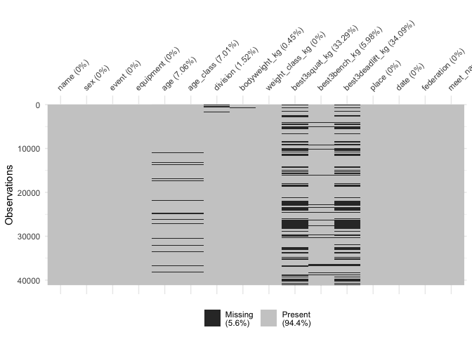

```r
vis_miss(ipf_lifts)
```

```r
ipf_lifts <- filter(ipf_lifts, !is.na(age))
ipf_lifts <- filter(ipf_lifts, !is.na(age_class))
ipf_lifts <- filter(ipf_lifts, !is.na(bodyweight_kg))
ipf_lifts <- filter(ipf_lifts, !is.na(best3squat_kg))
ipf_lifts <- filter(ipf_lifts, !is.na(best3bench_kg))
ipf_lifts <- filter(ipf_lifts, !is.na(best3deadlift_kg))
```

Then I will check the data again.

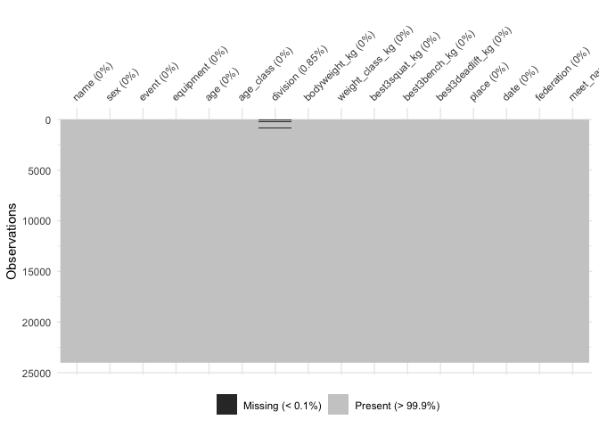

```r
vis_miss(ipf_lifts)
```

```r
ipf_lifts <- filter(ipf_lifts, !is.na(division))
```

And check the data again

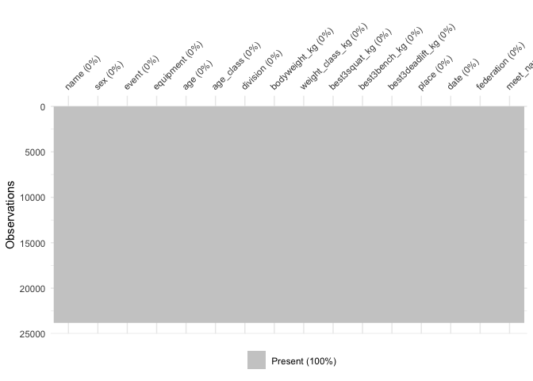

```r
vis_miss(ipf_lifts)
```

Now there is no missing data. I will now view the first rows of the dataset to check that everything looks tidy.

```r
head(ipf_lifts)
```

```
## # A tibble: 6 x 16
##   name  sex   event equipment   age age_class division bodyweight_kg
##   <chr> <chr> <chr> <chr>     <dbl> <chr>     <chr>            <dbl>
## 1 Anna… F     SBD   Single-p…  33.5 24-34     Open                44
## 2 Vuok… F     SBD   Single-p…  34.5 24-34     Open                44
## 3 Mari… F     SBD   Single-p…  23.5 24-34     Open                44
## 4 Hele… F     SBD   Single-p…  27.5 24-34     Open                44
## 5 Lijn… F     SBD   Single-p…  37.5 35-39     Open                44
## 6 Cari… F     SBD   Single-p…  25.5 24-34     Open                44
## # … with 8 more variables: weight_class_kg <chr>, best3squat_kg <dbl>,
## #   best3bench_kg <dbl>, best3deadlift_kg <dbl>, place <chr>, date <date>,
## #   federation <chr>, meet_name <chr>
```

**Does gender matter?**

Let’s first look at the effect of gender on squats applying violin plots

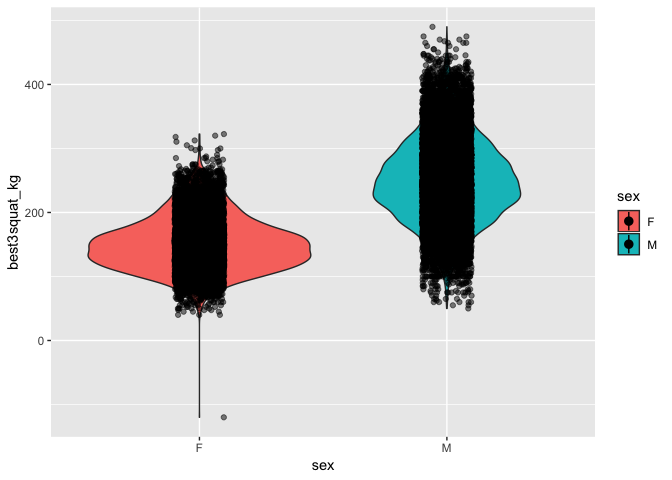

```r
ggplot(ipf_lifts, aes(x= sex, y= best3squat_kg, fill= sex)) +
  geom_violin() +
  geom_jitter(width=.1, alpha=.5) + stat_summary(fun.data="mean_cl_boot")
```

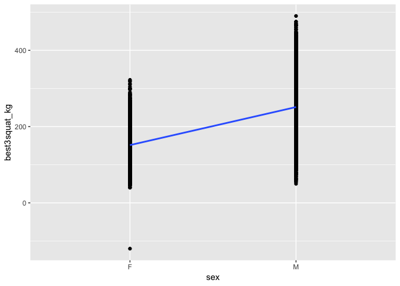

```r
ggplot(ipf_lifts, aes(x = sex, y = best3squat_kg, group = 1)) +
  geom_point() +
  geom_smooth(method = "lm")
```

This visualisation further illustrate an effect of gender on the number of squats completed within this sample. Let’s now see whether number of squats can be predicted by gender. I will first create my model that has one predictor (gender)

```r
ourmodel_sex <- lm(best3squat_kg ~ sex, data = ipf_lifts)
```

Then I will create my null model with no predictors for comparison.

```r
ourmodel_sex_0 <- lm(best3squat_kg ~ 1, data = ipf_lifts)
```

Finally, I will compare our models using the anova() function

```r
anova(ourmodel_sex_0, ourmodel_sex)
```

```
## Analysis of Variance Table
##
## Model 1: best3squat_kg ~ 1
## Model 2: best3squat_kg ~ sex
##   Res.Df       RSS Df Sum of Sq     F    Pr(>F)
## 1  23814 133018586
## 2  23813  78993920  1  54024666 16286 < 2.2e-16 ***
## ---
## Signif. codes:  0 '***' 0.001 '**' 0.01 '*' 0.05 '.' 0.1 ' ' 1
```

There seems to be an effect of our model. Let’s create a plot to check the residuals for our gender model.

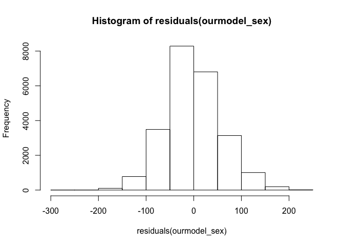

```r
hist(residuals(ourmodel_sex))
```

The residuals look normally distributed. Therefore, I will generate some coefficients, using the summary() function

```r
summary(ourmodel_sex)
```

```
##
## Call:
## lm(formula = best3squat_kg ~ sex, data = ipf_lifts)
##
## Residuals:
##      Min       1Q   Median       3Q      Max
## -271.487  -36.487   -3.681   33.819  238.819
##
## Coefficients:
##             Estimate Std. Error t value Pr(>|t|)
## (Intercept) 151.4869     0.6286   241.0   <2e-16 ***
## sexM         99.6939     0.7812   127.6   <2e-16 ***
## ---
## Signif. codes:  0 '***' 0.001 '**' 0.01 '*' 0.05 '.' 0.1 ' ' 1
##
## Residual standard error: 57.6 on 23813 degrees of freedom
## Multiple R-squared:  0.4061, Adjusted R-squared:  0.4061
## F-statistic: 1.629e+04 on 1 and 23813 DF,  p-value: < 2.2e-16
```

Gender seems to be a strong predictor of the model. Females were our reference category and the intercept (151.48) therefore corresponds to females. SexM (99.69) corresponds to the difference between our reference category and our Males in number of squats, meaning that for every 151.48 squats females do, males do 99.69 more. I will use the ggplot() function to graph our data. Using the “lm” method, I will generate a linear model (regression line)

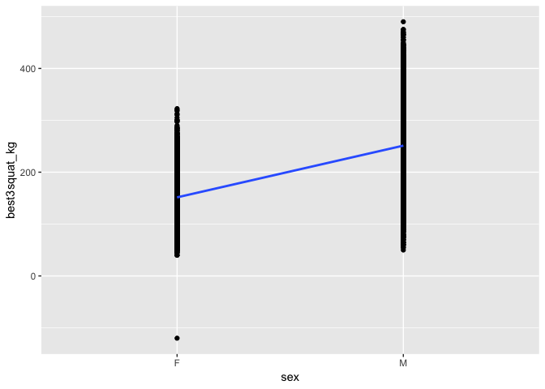

```r
ggplot(ipf_lifts, aes(x = sex, y = best3squat_kg, group = 1)) +
  geom_point() +
  geom_smooth(method = "lm")
```

This visualisation further illustrate that gender has an effect on the number of squats completed within this sample.

**Does age matter within the genders?**

I am also interested in knowing whether there are in-group differences for each gender. I will therefore create two new datasets that filter out the data for each gender to be able to look at the differneces occuring within the groups.

```r
ipf_lifts_females <- filter(ipf_lifts, (sex == "F"))
ipf_lifts_males <- filter(ipf_lifts, (sex == "M"))
```

Then I will check that the data looks okay for each filtered dataset.

```r
head(ipf_lifts_females)
```

```
## # A tibble: 6 x 16
##   name  sex   event equipment   age age_class division bodyweight_kg
##   <chr> <chr> <chr> <chr>     <dbl> <chr>     <chr>            <dbl>
## 1 Anna… F     SBD   Single-p…  33.5 24-34     Open                44
## 2 Vuok… F     SBD   Single-p…  34.5 24-34     Open                44
## 3 Mari… F     SBD   Single-p…  23.5 24-34     Open                44
## 4 Hele… F     SBD   Single-p…  27.5 24-34     Open                44
## 5 Lijn… F     SBD   Single-p…  37.5 35-39     Open                44
## 6 Cari… F     SBD   Single-p…  25.5 24-34     Open                44
## # … with 8 more variables: weight_class_kg <chr>, best3squat_kg <dbl>,
## #   best3bench_kg <dbl>, best3deadlift_kg <dbl>, place <chr>, date <date>,
## #   federation <chr>, meet_name <chr>
```

```r
head(ipf_lifts_males)
```

```
## # A tibble: 6 x 16
##   name  sex   event equipment   age age_class division bodyweight_kg
##   <chr> <chr> <chr> <chr>     <dbl> <chr>     <chr>            <dbl>
## 1 Hide… M     SBD   Single-p…  45   45-49     Open                52
## 2 P.K.… M     SBD   Single-p…  41.5 40-44     Open                52
## 3 Kari… M     SBD   Single-p…  40.5 40-44     Open                52
## 4 Chih… M     SBD   Single-p…  26.5 24-34     Open                52
## 5 Chao… M     SBD   Single-p…  33.5 24-34     Open                52
## 6 Moha… M     SBD   Single-p…  27.5 24-34     Open                52
## # … with 8 more variables: weight_class_kg <chr>, best3squat_kg <dbl>,
## #   best3bench_kg <dbl>, best3deadlift_kg <dbl>, place <chr>, date <date>,
## #   federation <chr>, meet_name <chr>
```

´ I will plot how people of different ages are squatting within each gender, to get a sense of the **shape** of this data.

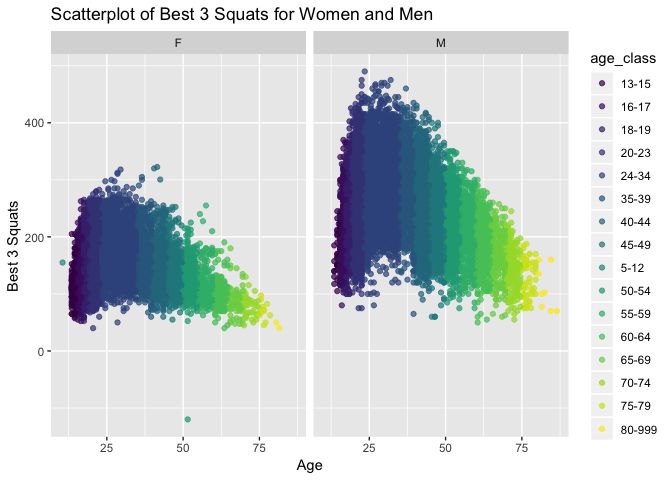

```r
ggplot(
  ipf_lifts,
  aes(x = age, y= best3squat_kg, colour = age_class)
) +
  geom_point(show.legend = TRUE, alpha = 0.7) +
  scale_color_viridis_d() +
  scale_size(range = c(2, 12)) +
  labs(x = "Age", y = "Best 3 Squats") +
  facet_wrap(~sex) +
  labs(title = "Scatterplot of Best 3 Squats for Women and Men")
```

My scatterplot illustrates that both genders seem to have a peak at the age of 25 and then decline in how much they are able to squat. As we can see the shapes are similar, but the peak is at a lower point for women than for men, which corresponds rightfully to my previous gender difference findings.. The higher the plots the more the squats each contestant is able to do. According to this visual model, both men and women seem peak around the age of 24-34. To know whether or not this is true I will run a linear model. First I will create my models separately for each gender

```r
ourmodel_women_squat <- lm(best3squat_kg ~ age, data = ipf_lifts_females)
ourmodel_men_squat <- lm(best3squat_kg ~ age, data = ipf_lifts_males)
```

Then I will create a null model for each gender

```r
model_women_squat_0 <- lm(best3squat_kg ~ 1, data = ipf_lifts_females)
model_men_squat_0 <- lm(best3squat_kg ~ 1, data = ipf_lifts_males)
```

Then I will compare my models using the anova() function

```r
anova(model_women_squat_0, ourmodel_women_squat)
```

```
## Analysis of Variance Table
##
## Model 1: best3squat_kg ~ 1
## Model 2: best3squat_kg ~ age
##   Res.Df      RSS Df Sum of Sq      F    Pr(>F)
## 1   8394 14835358
## 2   8393 14118555  1    716803 426.12 < 2.2e-16 ***
## ---
## Signif. codes:  0 '***' 0.001 '**' 0.01 '*' 0.05 '.' 0.1 ' ' 1
```

```r
anova(model_men_squat_0, ourmodel_men_squat)
```

```
## Analysis of Variance Table
##
## Model 1: best3squat_kg ~ 1
## Model 2: best3squat_kg ~ age
##   Res.Df      RSS Df Sum of Sq      F    Pr(>F)
## 1  15419 64158562
## 2  15418 58956462  1   5202101 1360.4 < 2.2e-16 ***
## ---
## Signif. codes:  0 '***' 0.001 '**' 0.01 '*' 0.05 '.' 0.1 ' ' 1
```

My ANOVAs suggest the models with all of the predictors are the better models for both women and men. I will create two histograms to check that my residuals are normally distributed.

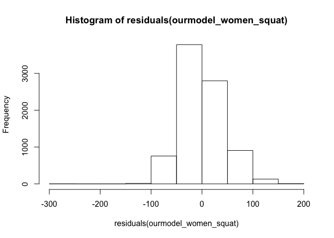

```r
hist(residuals(ourmodel_women_squat))
```

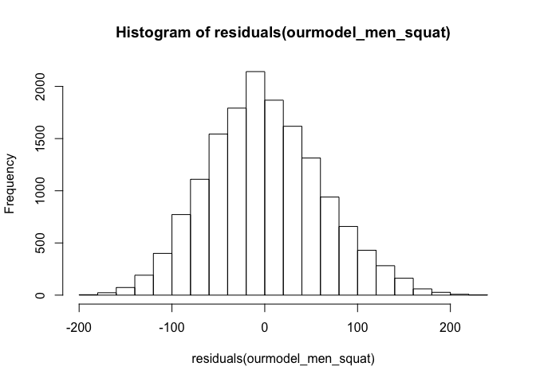

```r
hist(residuals(ourmodel_men_squat))
```

For women, the residuals appear slightly skewed, whilst for men there is a perfect normal distribution. I will create some more plots for the women-data to see whether it is appropriate for the model.

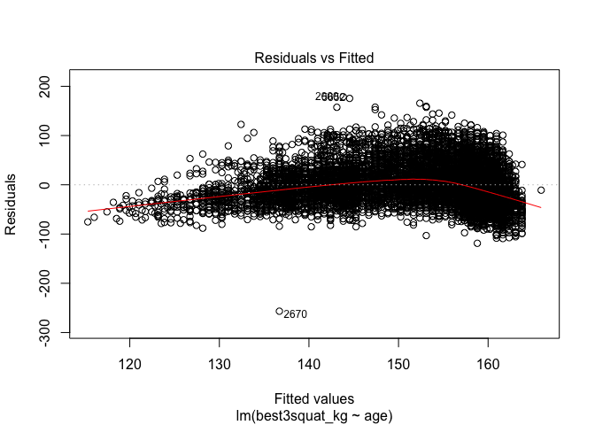

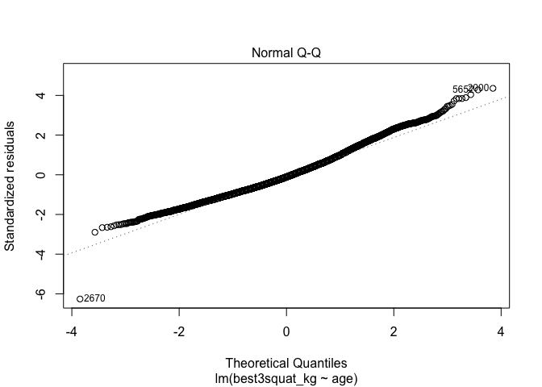

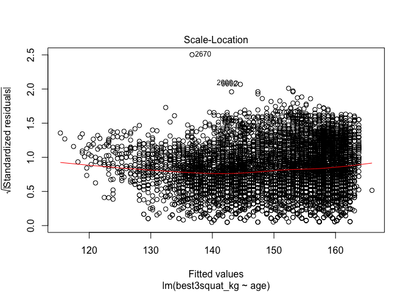

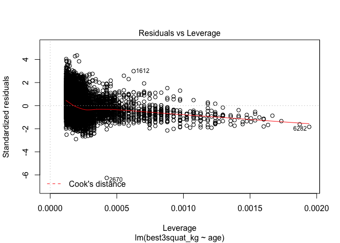

```r
plot(ourmodel_women_squat)
```

The data seems appropriate. I will now create some coefficients for both datasets using the summary function

```r
summary(ourmodel_women_squat)
```

```
##
## Call:
## lm(formula = best3squat_kg ~ age, data = ipf_lifts_females)
##
## Residuals:
##     Min      1Q  Median      3Q     Max
## -256.70  -29.19   -4.53   24.42  178.67
##
## Coefficients:
##              Estimate Std. Error t value Pr(>|t|)
## (Intercept) 173.40792    1.15242  150.47   <2e-16 ***
## age          -0.71278    0.03453  -20.64   <2e-16 ***
## ---
## Signif. codes:  0 '***' 0.001 '**' 0.01 '*' 0.05 '.' 0.1 ' ' 1
##
## Residual standard error: 41.01 on 8393 degrees of freedom
## Multiple R-squared:  0.04832,    Adjusted R-squared:  0.0482
## F-statistic: 426.1 on 1 and 8393 DF,  p-value: < 2.2e-16
```

```r
summary(ourmodel_men_squat)
```

```
##
## Call:
## lm(formula = best3squat_kg ~ age, data = ipf_lifts_males)
##
## Residuals:
##      Min       1Q   Median       3Q      Max
## -193.864  -43.124   -3.172   40.585  225.559
##
## Coefficients:
##              Estimate Std. Error t value Pr(>|t|)
## (Intercept) 293.96706    1.26239  232.87   <2e-16 ***
## age          -1.25643    0.03406  -36.88   <2e-16 ***
## ---
## Signif. codes:  0 '***' 0.001 '**' 0.01 '*' 0.05 '.' 0.1 ' ' 1
##
## Residual standard error: 61.84 on 15418 degrees of freedom
## Multiple R-squared:  0.08108,    Adjusted R-squared:  0.08102
## F-statistic:  1360 on 1 and 15418 DF,  p-value: < 2.2e-16
```

For both men and women there seems to be an effect of age. Specifically, the older women get, the number of squats they do decline with .71. The older men get their squat number declines with 1.26. What is also notable is that the intercept for men is higher (293.96) than for women (173.41), meaning that even though the number of squats they do decline more rapidly with age, they also peak at a higher number of squats, which is consistent with our scatterplot

Now I want to check the weight distribution on the ages within the squatters of each gender. Seeing as squatters within both genders do the most squats at 25 and this declines with age, I am wondering whether the bodyweight of these squatters also decline with age.

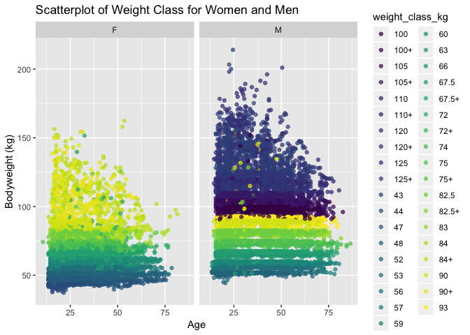

```r
ggplot(
  ipf_lifts,
  aes(x = age, y= bodyweight_kg, colour = weight_class_kg)
) +
  geom_point(show.legend = TRUE, alpha = 0.7) +
  scale_color_viridis_d() +
  scale_size(range = c(2, 12)) +
  labs(x = "Age", y = "Bodyweight (kg)") +
  facet_wrap(~sex) +
  labs(title = "Scatterplot of Weight Class for Women and Men")
```

Our scatterplot illustrates that as age decline from just before 25, so does the weight of the squatter. Therefore, I will add this predictor to the linear model.

```r
ourmodel_women_squat_weight <- lm(best3squat_kg ~ age + bodyweight_kg, data = ipf_lifts_females)
ourmodel_men_squat_weight <- lm(best3squat_kg ~ age + bodyweight_kg, data = ipf_lifts_males)
```

Then I will compare these with the NULL models using the anova() function.

```r
anova(model_women_squat_0, ourmodel_women_squat_weight)
```

```
## Analysis of Variance Table
##
## Model 1: best3squat_kg ~ 1
## Model 2: best3squat_kg ~ age + bodyweight_kg
##   Res.Df      RSS Df Sum of Sq      F    Pr(>F)
## 1   8394 14835358
## 2   8392  9608804  2   5226554 2282.3 < 2.2e-16 ***
## ---
## Signif. codes:  0 '***' 0.001 '**' 0.01 '*' 0.05 '.' 0.1 ' ' 1
```

```r
anova(model_men_squat_0, ourmodel_men_squat_weight)
```

```
## Analysis of Variance Table
##
## Model 1: best3squat_kg ~ 1
## Model 2: best3squat_kg ~ age + bodyweight_kg
##   Res.Df      RSS Df Sum of Sq      F    Pr(>F)
## 1  15419 64158562
## 2  15417 32636593  2  31521970 7445.2 < 2.2e-16 ***
## ---
## Signif. codes:  0 '***' 0.001 '**' 0.01 '*' 0.05 '.' 0.1 ' ' 1
```

Both anova’s suggest the models with the predictors are much stronger than the null models. Then I will again generate some coefficients

```r
summary(ourmodel_women_squat_weight)
```

```
##
## Call:
## lm(formula = best3squat_kg ~ age + bodyweight_kg, data = ipf_lifts_females)
##
## Residuals:
##      Min       1Q   Median       3Q      Max
## -264.404  -22.467   -1.521   20.766  103.481
##
## Coefficients:
##               Estimate Std. Error t value Pr(>|t|)
## (Intercept)   86.56067    1.67897   51.56   <2e-16 ***
## age           -0.70826    0.02849  -24.86   <2e-16 ***
## bodyweight_kg  1.33408    0.02126   62.76   <2e-16 ***
## ---
## Signif. codes:  0 '***' 0.001 '**' 0.01 '*' 0.05 '.' 0.1 ' ' 1
##
## Residual standard error: 33.84 on 8392 degrees of freedom
## Multiple R-squared:  0.3523, Adjusted R-squared:  0.3521
## F-statistic:  2282 on 2 and 8392 DF,  p-value: < 2.2e-16
```

```r
summary(ourmodel_men_squat_weight)
```

```
##
## Call:
## lm(formula = best3squat_kg ~ age + bodyweight_kg, data = ipf_lifts_males)
##
## Residuals:
##      Min       1Q   Median       3Q      Max
## -262.110  -28.980   -0.144   29.738  157.269
##
## Coefficients:
##                Estimate Std. Error t value Pr(>|t|)
## (Intercept)   145.09836    1.63240   88.89   <2e-16 ***
## age            -1.35583    0.02536  -53.46   <2e-16 ***
## bodyweight_kg   1.73151    0.01553  111.50   <2e-16 ***
## ---
## Signif. codes:  0 '***' 0.001 '**' 0.01 '*' 0.05 '.' 0.1 ' ' 1
##
## Residual standard error: 46.01 on 15417 degrees of freedom
## Multiple R-squared:  0.4913, Adjusted R-squared:  0.4912
## F-statistic:  7445 on 2 and 15417 DF,  p-value: < 2.2e-16
```

**Does type of equipment people use influence for the number of squats they do?**

Now let’s look at what type of equipment people use within each gender

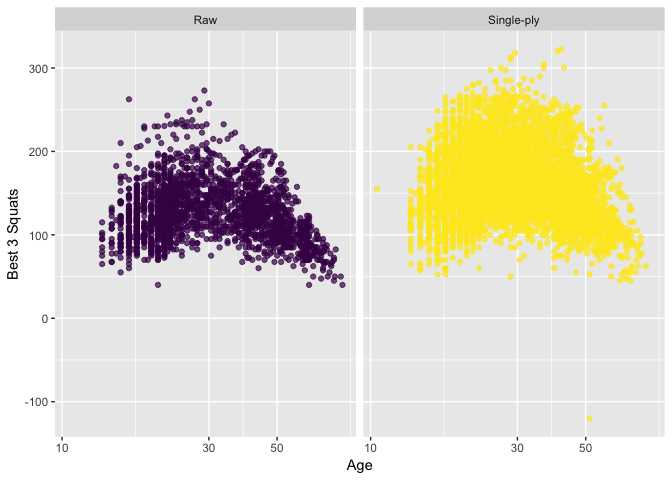

```r
ggplot(
  ipf_lifts_females,
  aes(x = age, y= best3squat_kg, colour = equipment)
) +
  geom_point(show.legend = FALSE, alpha = 0.7) + facet_wrap(~equipment) +
  scale_color_viridis_d() +
  scale_size(range = c(2, 12)) +
  scale_x_log10() +
  labs(x = "Age", y = "Best 3 Squats")
```

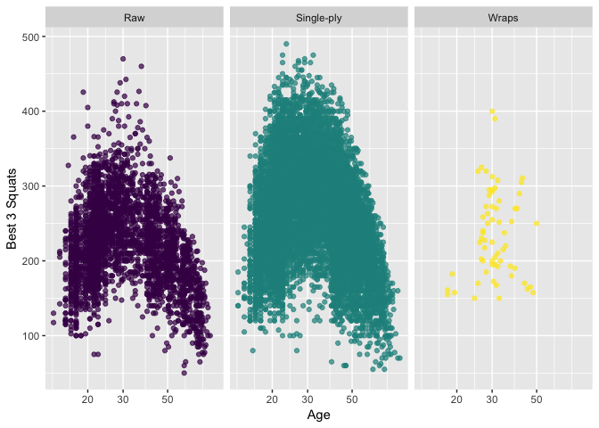

```r
ggplot(
  ipf_lifts_males,
  aes(x = age, y= best3squat_kg, colour = equipment)
) +
  geom_point(show.legend = FALSE, alpha = 0.7) + facet_wrap(~equipment) +
  scale_color_viridis_d() +
  scale_size(range = c(2, 12)) +
  scale_x_log10() +
  labs(x = "Age", y = "Best 3 Squats")
```

```r
ourmodel_women_squat_weight_equip <- lm(best3squat_kg ~ age + bodyweight_kg + equipment, data = ipf_lifts_females)
ourmodel_men_squat_weight_equip <- lm(best3squat_kg ~ age + bodyweight_kg + equipment, data = ipf_lifts_males)
```

Then I will compare these with the NULL models using the anova() function.

```r
anova(model_women_squat_0, ourmodel_women_squat_weight_equip)
```

```
## Analysis of Variance Table
##
## Model 1: best3squat_kg ~ 1
## Model 2: best3squat_kg ~ age + bodyweight_kg + equipment
##   Res.Df      RSS Df Sum of Sq      F    Pr(>F)
## 1   8394 14835358
## 2   8391  7892395  3   6942963 2460.5 < 2.2e-16 ***
## ---
## Signif. codes:  0 '***' 0.001 '**' 0.01 '*' 0.05 '.' 0.1 ' ' 1
```

```r
anova(model_men_squat_0, ourmodel_men_squat_weight_equip)
```

```
## Analysis of Variance Table
##
## Model 1: best3squat_kg ~ 1
## Model 2: best3squat_kg ~ age + bodyweight_kg + equipment
##   Res.Df      RSS Df Sum of Sq      F    Pr(>F)
## 1  15419 64158562
## 2  15415 28515108  4  35643454 4817.1 < 2.2e-16 ***
## ---
## Signif. codes:  0 '***' 0.001 '**' 0.01 '*' 0.05 '.' 0.1 ' ' 1
```

Both anova’s suggest the models with the predictors are much stronger than the null models.

I will create a plot for each model to check their residuals.

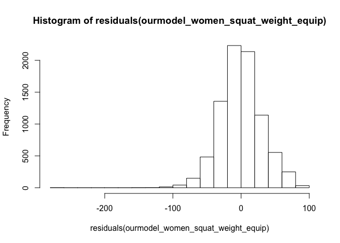

```r
hist(residuals(ourmodel_women_squat_weight_equip))
```

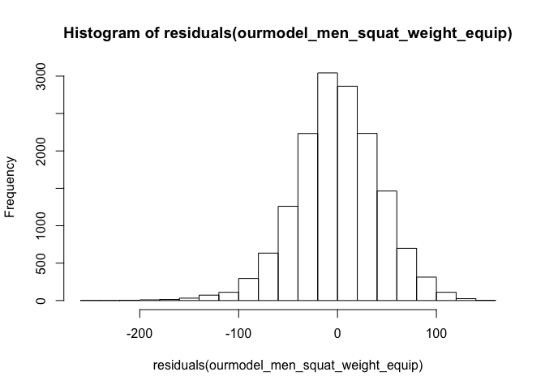

```r
hist(residuals(ourmodel_men_squat_weight_equip))
```

Both residual models look slightly skewed to the left. I will create some more plots to see whether the data is appropriate for the models

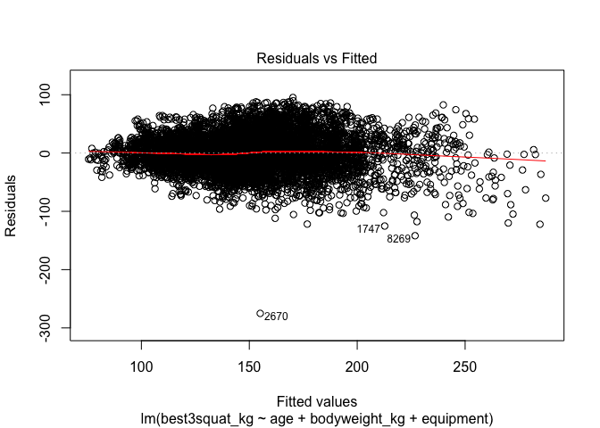

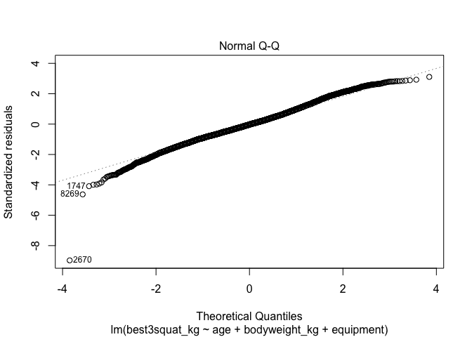

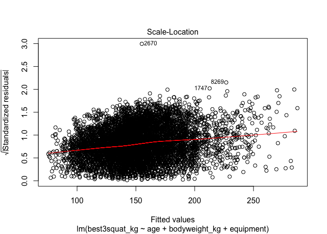

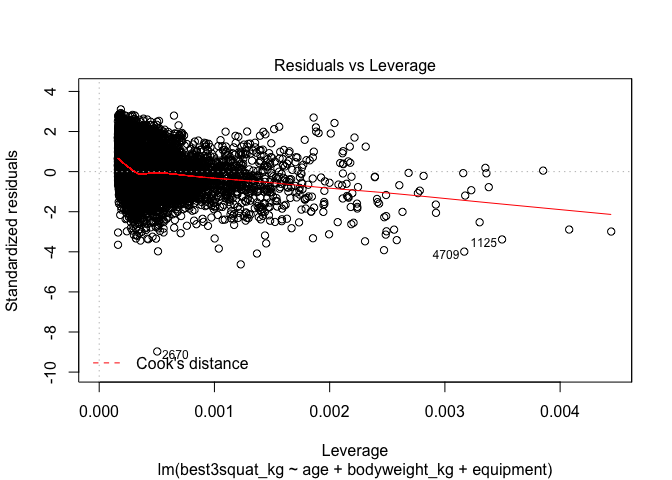

```r
plot(ourmodel_women_squat_weight_equip)
```

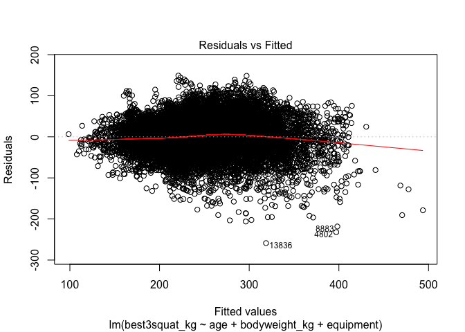

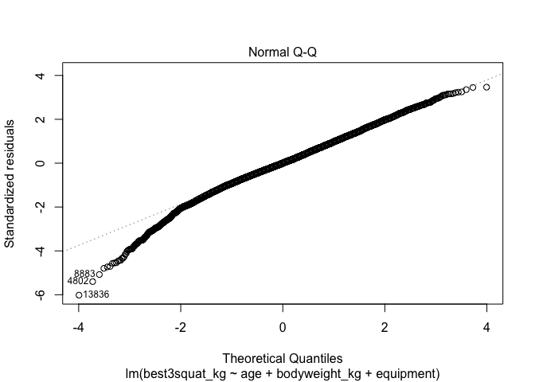

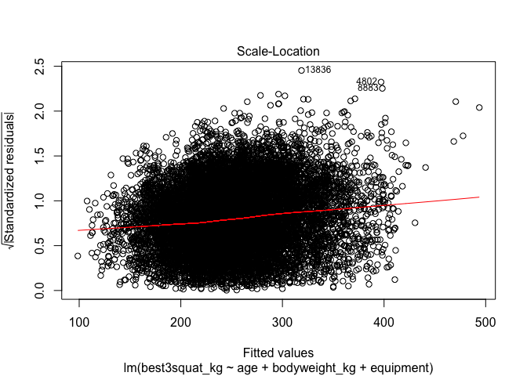

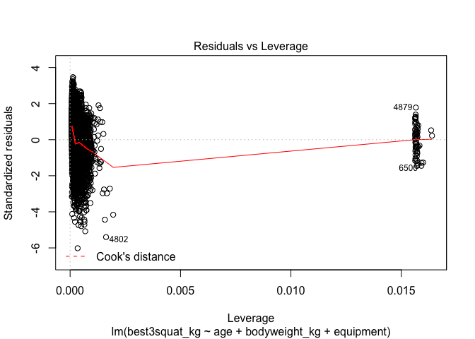

```r
plot(ourmodel_men_squat_weight_equip)
```

The values for both genders seem to be within cook’s distance. Finally, I will check for multicollinearity measured by VIF

```r
vif(ourmodel_women_squat_weight_equip)
```

```
##           age bodyweight_kg     equipment
##      1.007280      1.001583      1.008833
```

```r
vif(ourmodel_men_squat_weight_equip)
```

```
##                   GVIF Df GVIF^(1/(2*Df))
## age           1.001737  1        1.000868
## bodyweight_kg 1.002957  1        1.001477
## equipment     1.002193  2        1.000548
```

There seems to be no multicollinearity, suggesting my results are trustworthy

Then I will again generate some coefficients

```r
summary(ourmodel_women_squat_weight_equip)
```

```
##
## Call:
## lm(formula = best3squat_kg ~ age + bodyweight_kg + equipment,
##     data = ipf_lifts_females)
##
## Residuals:
##      Min       1Q   Median       3Q      Max
## -275.072  -19.510   -0.778   18.568   95.279
##
## Coefficients:
##                     Estimate Std. Error t value Pr(>|t|)
## (Intercept)         57.36196    1.66820   34.39   <2e-16 ***
## age                 -0.61419    0.02591  -23.70   <2e-16 ***
## bodyweight_kg        1.36675    0.01928   70.88   <2e-16 ***
## equipmentSingle-ply 32.71158    0.76575   42.72   <2e-16 ***
## ---
## Signif. codes:  0 '***' 0.001 '**' 0.01 '*' 0.05 '.' 0.1 ' ' 1
##
## Residual standard error: 30.67 on 8391 degrees of freedom
## Multiple R-squared:  0.468,  Adjusted R-squared:  0.4678
## F-statistic:  2461 on 3 and 8391 DF,  p-value: < 2.2e-16
```

```r
summary(ourmodel_men_squat_weight_equip)
```

```
##
## Call:
## lm(formula = best3squat_kg ~ age + bodyweight_kg + equipment,
##     data = ipf_lifts_males)
##
## Residuals:
##      Min       1Q   Median       3Q      Max
## -258.762  -26.331    0.007   28.368  148.983
##
## Coefficients:
##                      Estimate Std. Error t value Pr(>|t|)
## (Intercept)         111.67722    1.68359  66.333  < 2e-16 ***
## age                  -1.37835    0.02371 -58.126  < 2e-16 ***
## bodyweight_kg         1.75352    0.01453 120.695  < 2e-16 ***
## equipmentSingle-ply  40.58984    0.85993  47.201  < 2e-16 ***
## equipmentWraps       30.83907    5.43312   5.676  1.4e-08 ***
## ---
## Signif. codes:  0 '***' 0.001 '**' 0.01 '*' 0.05 '.' 0.1 ' ' 1
##
## Residual standard error: 43.01 on 15415 degrees of freedom
## Multiple R-squared:  0.5556, Adjusted R-squared:  0.5554
## F-statistic:  4817 on 4 and 15415 DF,  p-value: < 2.2e-16
```

These models also suggest equipment matters for the number of squats completed, with 32.7 more squats being completed when using single-ply equipment for women, and 40.6 more squats being completed when using single-ply for men, and 30.8 more being completed when using wraps for men.

# References

John Fox and Sanford Weisberg (2011). An {R} Companion to Applied Regression, Second Edition. Thousand Oaks CA: Sage. URL: http://socserv.socsci.mcmaster.ca/jfox/Books/Companion

Tierney N (2017). “visdat: Visualising Whole Data Frames.” *JOSS*, *2*(16), 355. doi: 10.21105/joss.00355 (URL: http://doi.org/10.21105/joss.00355), <URL: http://dx.doi.org/10.21105/joss.00355>.

Hadley Wickham (2017). tidyverse: Easily Install and Load the ‘Tidyverse’. R package version 1.2.1. https://CRAN.R-project.org/package=tidyverse

H. Wickham. ggplot2: Elegant Graphics for Data Analysis. Springer-Verlag New York, 2016.

Yixuan Qiu (2019). prettydoc: Creating Pretty Documents from R Markdown. R package version 0.3.0. https://CRAN.R-project.org/package=prettydoc